# DataFest 2019 Introduction to Neural Nets and Keras

Marcel Neunhoeffer - University of Mannheim

03 May 2019

# Introduction to Keras

[Keras](https://keras.io) is a high-level neural networks API, written in Python and capable of running on top of TensorFlow, CNTK, or Theano. It was developed with a focus on enabling fast experimentation. Being able to go from idea to result with the least possible delay is key to doing good research.

Use Keras if you need a deep learning library that:

- Allows for easy and fast prototyping (through user friendliness, modularity, and extensibility).
- Supports both convolutional networks and recurrent networks, as well as combinations of the two.
- Runs seamlessly on CPU and GPU.
- Runs on Python as well as in R!

## Installing Keras

Keras in R will need the python libraries of keras and tensorflow to run in the background. Therefore, the installation of the package is slightly different than with usual R-packages.

```r
devtools::install_github("rstudio/keras")
library(keras)
install_keras()
```

## A first pseudo model in Keras

Models in Keras always follow the same structure

### Prepare the data

```r
sel <- sample(nrow(data), floor(0.7 * nrow(data)))

x_train <- as.matrix(data[sel, Xcolumns])
y_train <- data[sel, ycolumn]

x_test <- as.matrix(data[-sel, Xcolumns])
y_test <- data[-sel, ycolumns]
```

### Define

```r
model <- keras_model_sequential()
model %>%
  layer_dense(units = 1,
              activation = 'sigmoid',
              input_shape = c(2))
```

### Compile

```r
model %>% compile(
  loss = 'binary_crossentropy',
  optimizer = optimizer_rmsprop(),
  metrics = c('accuracy')
)
```

### Fit:

```r
history <- model %>% fit(
  x_train,
  y_train,
  epochs = 30,
  batch_size = 128,
  validation_split = 0.2
)

plot(history)
```

### Evaluate:

```r
model %>% evaluate(x_test, y_test)
```

### Predict:

```r
model %>% predict_classes(x_test)
```

# Logit Regression in Keras

```r
two_spirals <- function(N = 1000,
                        radians = 3 * pi,
                        theta0 = pi / 2,
                        labels = 0:1) {
  N1 <- floor(N / 2)
  N2 <- N - N1

  theta <- theta0 + runif(N1) * radians
  spiral1 <- cbind(-theta * cos(theta) + runif(N1),
                   theta * sin(theta) + runif(N1))
  spiral2 <-
    cbind(theta * cos(theta) + runif(N2), -theta * sin(theta) + runif(N2))

  points <- rbind(spiral1, spiral2)
  classes <- c(rep(0, N1), rep(1, N2))

  data.frame(
    x1 = points[, 1],
    x2 = points[, 2],
    class = factor(classes, labels = labels)
  )
}

set.seed(42)
df <- two_spirals(labels = c('Yay', 'Nay'))
```

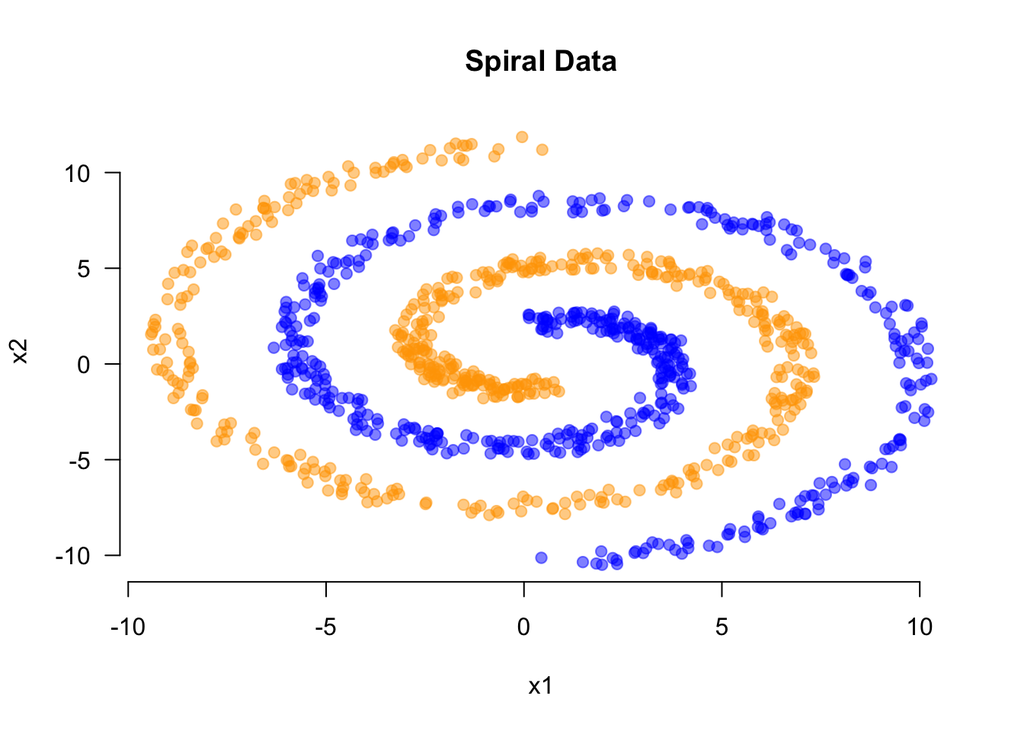

```r
plot(
  df$x1,
  df$x2,
  xlab = "x1",
  ylab = "x2",
  main = "Spiral Data",
  col = ifelse(
    df$class == "Yay",
    adjustcolor("blue", alpha = 0.5),
    adjustcolor("orange", alpha = 0.5)
  ),
  pch = 19,
  bty = "n",
  las = 1
)
```

**What do you think: How would a logit model divide the data?**

Let’s find out!

## Prepare the data for keras

```r
# Select a random sample
sel <- sample(1:1000, 700)

x_train <- as.matrix(df[sel, 1:2])
y_train <- ifelse(df[sel, 3] == "Yay", 1, 0)

x_test <- as.matrix(df[-sel, 1:2])
y_test <- ifelse(df[-sel, 3] == "Yay", 1, 0)
```

## Define the keras model

```r
model <- keras_model_sequential()
model %>%
  layer_dense(units = 1,
              activation = 'sigmoid',
              input_shape = c(2))
```

## Compile the keras model

```r
model %>% compile(
  loss = 'binary_crossentropy',
  optimizer = optimizer_rmsprop(),
  metrics = c('accuracy')
)
```

## Fit the model

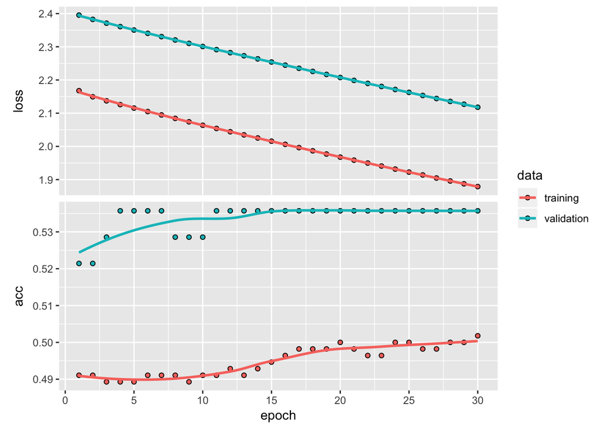

```r
history <- model %>% fit(
  x_train,
  y_train,
  epochs = 30,
  batch_size = 128,
  validation_split = 0.2
)

plot(history)
```

## Evaluate the model

```r
model %>% evaluate(x_test, y_test)
```

```
## $loss
## [1] 1.709692
##
## $acc
## [1] 0.5866667
```

## Make predictions with the model

```r
# Predict class labels
y_pred <- model %>% predict_classes(x_test)

# Predicted probabilities
y_pred_prob <- model %>% predict(x_test)
```

## Plot the predictions

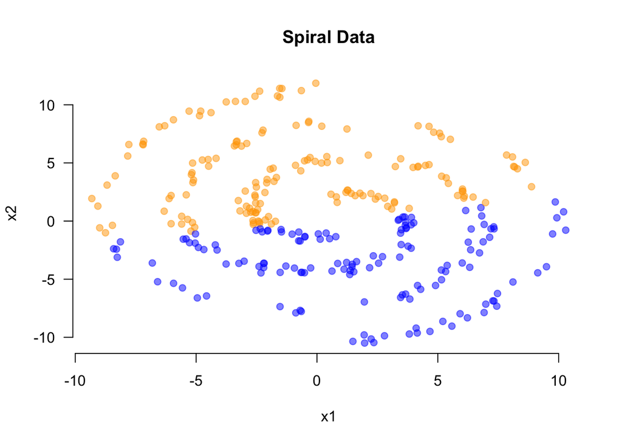

```r
plot(
  x_test[, 1],
  x_test[, 2],
  xlab = "x1",
  ylab = "x2",
  main = "Spiral Data",
  col = ifelse(
    y_pred == 1,
    adjustcolor("blue", alpha = 0.5),
    adjustcolor("orange", alpha = 0.5)
  ),
  pch = 19,
  bty = "n",
  las = 1
)
```

## Plot the decision surface

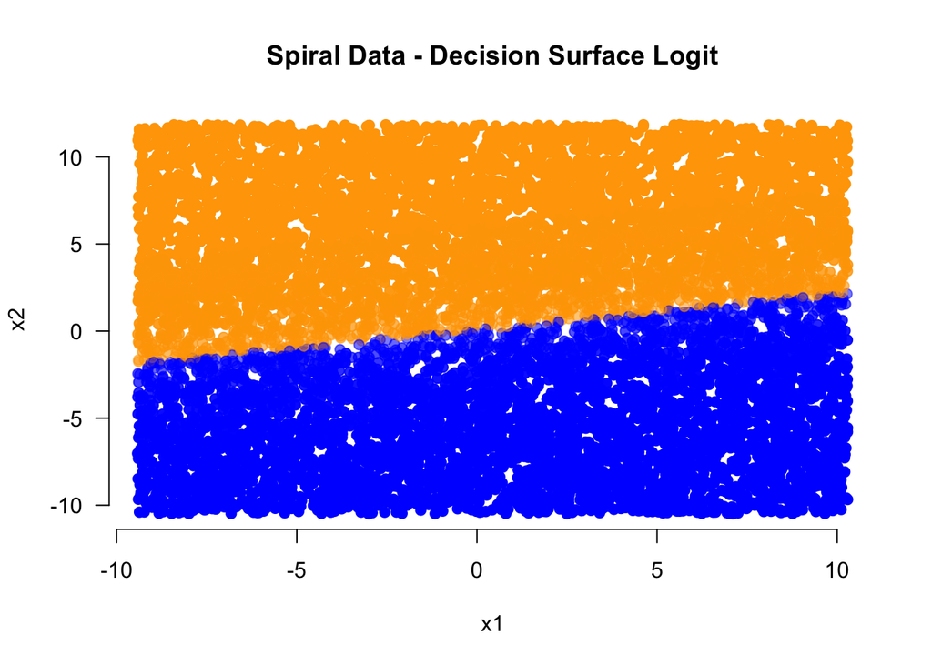

```r
x_surface <-
  cbind(runif(10000, min = min(df$x1), max = max(df$x1)),
        runif(10000, min = min(df$x2), max = max(df$x2)))

# Predicted probabilities
y_pred_prob_surface <- model %>% predict(x_surface)

col_val <- NULL
for (i in 1:nrow(y_pred_prob_surface)) {
  col_val <-
    c(col_val,
      ifelse(
        y_pred_prob_surface[i] > 0.5,
        adjustcolor("blue", alpha = y_pred_prob_surface[i]),
        adjustcolor("orange", alpha = 1 - y_pred_prob_surface[i])
      ))
}

plot(
  x_surface[, 1],
  x_surface[, 2],
  xlab = "x1",
  ylab = "x2",
  main = "Spiral Data - Decision Surface Logit",
  col = col_val,
  pch = 19,
  bty = "n",
  las = 1
)
```

That’s a bit disappointing.

Our hope is that a neural net could do a better job!

# Neural Nets

Now you will see how simple it is to code a neural net in keras. In fact we only have to make simple changes to our code.

## Define the keras model

```r
model <- keras_model_sequential()
model %>%
  layer_dense(units = 128,
              activation = 'relu',
              input_shape = c(2)) %>%
  layer_dense(units = 64, activation = 'relu') %>%
  layer_dense(units = 1, activation = 'sigmoid')

summary(model)
```

```
## ___________________________________________________________________________
## Layer (type)                     Output Shape                  Param #
## ===========================================================================
## dense_2 (Dense)                  (None, 128)                   384
## ___________________________________________________________________________
## dense_3 (Dense)                  (None, 64)                    8256
## ___________________________________________________________________________
## dense_4 (Dense)                  (None, 1)                     65
## ===========================================================================
## Total params: 8,705
## Trainable params: 8,705
## Non-trainable params: 0
## ___________________________________________________________________________
```

## Compile the keras model

```r
model %>% compile(
  loss = 'binary_crossentropy',
  optimizer = optimizer_rmsprop(),
  metrics = c('accuracy')
)
```

## Fit the model

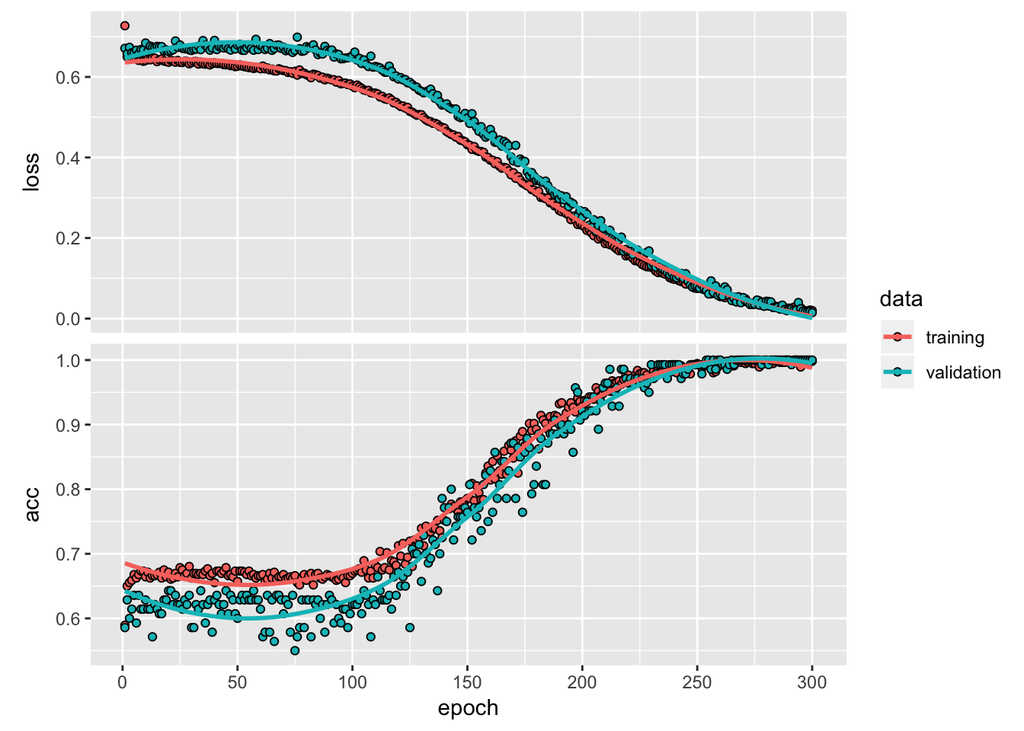

```r
history <- model %>% fit(
  x_train,
  y_train,
  epochs = 300,
  batch_size = 128,
  validation_split = 0.2
)

plot(history)
```

## Evaluate the model

```r
model %>% evaluate(x_test, y_test)
```

```
## $loss
## [1] 0.02036079
##
## $acc
## [1] 1
```

## Make predictions with the model

```r
# Predict class labels
y_pred <- model %>% predict_classes(x_test)

# Predicted probabilities
y_pred_prob <- model %>% predict(x_test)
```

## Plot the predictions

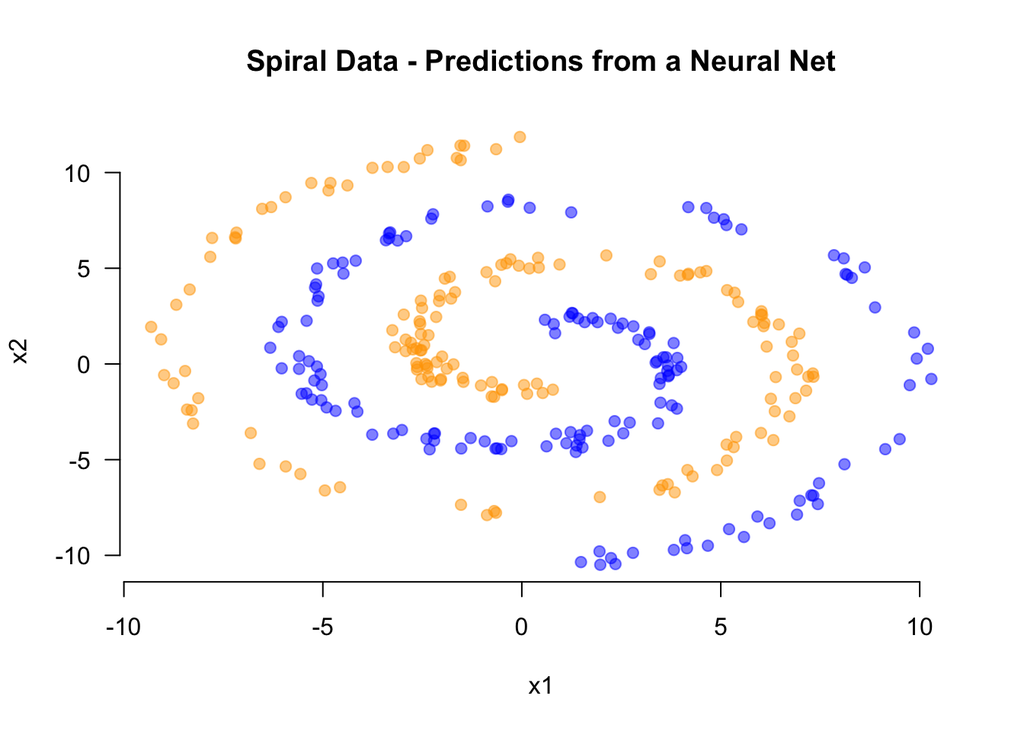

```r
plot(
  x_test[, 1],
  x_test[, 2],
  xlab = "x1",
  ylab = "x2",
  main = "Spiral Data - Predictions from a Neural Net",
  col = ifelse(
    y_pred == 1,
    adjustcolor("blue", alpha = 0.5),
    adjustcolor("orange", alpha = 0.5)
  ),
  pch = 19,
  bty = "n",
  las = 1
)
```

## Plot the prediction surface

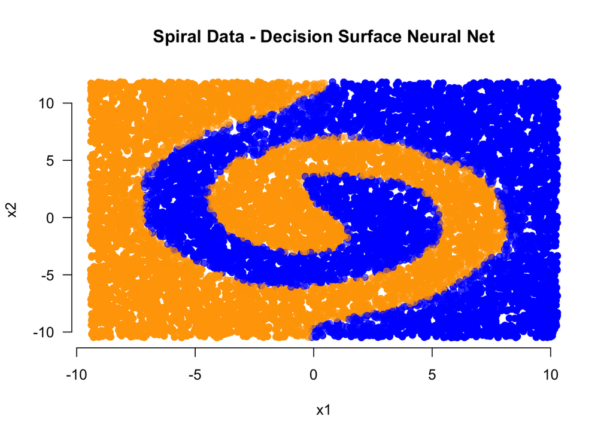

```r
x_surface <-
  cbind(runif(10000, min = min(df$x1), max = max(df$x1)),
        runif(10000, min = min(df$x2), max = max(df$x2)))

# Predicted probabilities
y_pred_prob_surface <- model %>% predict(x_surface)

col_val <- NULL
for (i in 1:nrow(y_pred_prob_surface)) {
  col_val <-
    c(col_val,
      ifelse(
        y_pred_prob_surface[i] > 0.5,
        adjustcolor("blue", alpha = y_pred_prob_surface[i]),
        adjustcolor("orange", alpha = 1 - y_pred_prob_surface[i])
      ))
}

plot(
  x_surface[, 1],
  x_surface[, 2],
  xlab = "x1",
  ylab = "x2",
  main = "Spiral Data - Decision Surface Neural Net",
  col = col_val,
  pch = 19,
  bty = "n",
  las = 1
)
```

# Tuning a neural net

There are many things to consider in each step of coding a neural net.

Models in Keras always follow the same structure

**Prepare the data:**

```r
sel <- sample(nrow(data), floor(0.7 * nrow(data)))

x_train <- data[sel, Xcolumns]
y_train <- data[sel, ycolumn]

x_test <- data[-sel, Xcolumns]
y_test <- data[-sel, ycolumns]
```

- How do you want to split your data?
- What if your data is not i.i.d (E.g. Time-Series data)?

**Define:**

```r
model <- keras_model_sequential()
model %>%
  layer_dense(units = 1,
              activation = 'sigmoid',
              input_shape = c(2))
```

You can experiment with:

- The number of layers.
- The number of units per layer (have a look at popular neural net architectures).
- The activation function for each layer.

Additionally:

- How to deal with overfitting?
- Regularization?
- Dropout?

**Compile:**

```r
model %>% compile(
  loss = 'binary_crossentropy',
  optimizer = optimizer_rmsprop(),
  metrics = c('accuracy')
)
```

- What is the loss function for your problem?
- What evaluation metrics do you want to look at?
- Choose a different optimizer.

**Fit:**

```r
history <- model %>% fit(
  x_train,
  y_train,
  epochs = 30,
  batch_size = 128,
  validation_split = 0.2
)

plot(history)
```

- For how many epochs do you want to train your net?
- How big should one training batch be?
- How much data do you want to have in you validation set?